# M3T2_FirstContact

Ale F. Benages

3/30/2021

# Library

```r
library(caret, ggplot2)
library(ggridges)
library(plyr)
#library(tictoc)
set.seed(9982)
```

# Load CSV

```r
path_to_file <- "//home/ale/Dropbox/UBIQUM/3.DAwithR/Task2:Classification.in.R/SurveyData/CompleteResponses.csv"

ComResp <- read.csv(path_to_file)

str(ComResp) # with srt() we can see the structure of the dataframe
```

```
## 'data.frame':    9898 obs. of  7 variables:
##  $ salary : num  119807 106880 78021 63690 50874 ...
##  $ age    : int  45 63 23 51 20 56 24 62 29 41 ...
##  $ elevel : int  0 1 0 3 3 3 4 3 4 1 ...
##  $ car    : int  14 11 15 6 14 14 8 3 17 5 ...
##  $ zipcode: int  4 6 2 5 4 3 5 0 0 4 ...
##  $ credit : num  442038 45007 48795 40889 352951 ...
##  $ brand  : int  0 1 0 1 0 1 1 1 0 1 ...
```

```r
# head(ComResp) # with head we get a similar output but with the classic dataframe structure
```

# EDA

## Some Plots and description of variables.

### 1. Salary

Survey Questions and Response Key  
1) What is your yearly salary, not including bonuses?. Respondents enter numeric value

- **This is a numerical variable.**

```r
summary(ComResp$salary)
```

```
##    Min. 1st Qu.  Median    Mean 3rd Qu.    Max.
##   20000   52082   84950   84871  117162  150000
```

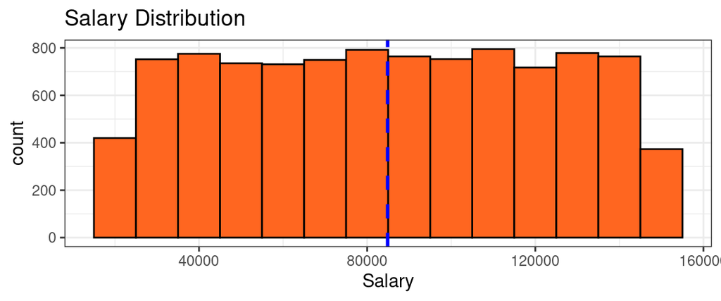

```r
ggplot( ComResp, aes(x=salary)) + theme_bw()+
  geom_histogram(color = 'black', fill = '#FF6620', binwidth = 10000)+
  labs(title = "Salary Distribution", x="Salary") +
  geom_vline(aes(xintercept=mean(salary)), color="blue", linetype="dashed", size=1)  # adds the mean
```

### 2. Age

Survey Questions and Response Key  
2) What is your age?. Respondents enter numeric value

- ** This is a Numerical Variable**

```r
summary(ComResp$age)
```

```
##    Min. 1st Qu.  Median    Mean 3rd Qu.    Max.
##   20.00   35.00   50.00   49.78   65.00   80.00
```

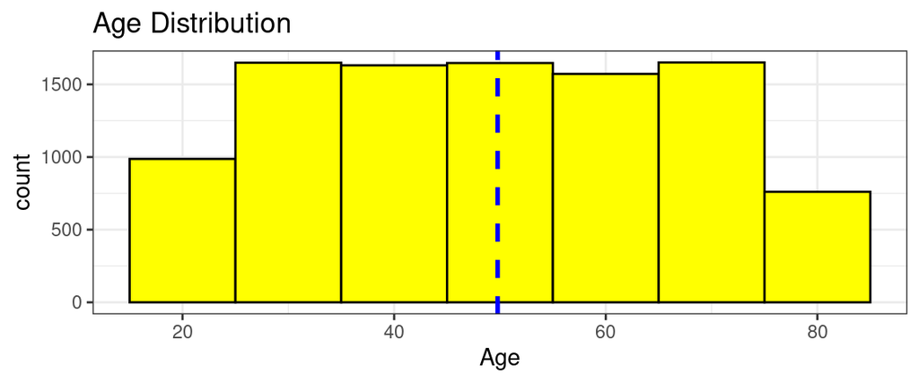

```r
ggplot( ComResp, aes(x=age)) + theme_bw()+
  geom_histogram(color = 'black', fill = 'yellow', binwidth = 10)+
  labs(title = "Age Distribution", x="Age") +
  geom_vline(aes(xintercept=mean(age)), color="blue", linetype="dashed", size=1)  # adds the mean
```

### 3. elevel - Education Level

3. What is the highest level of education you have obtained?. Respondents select from the following 5 choices:  
   Value : Description  
   0 : Less than High School Degree  
   1 : High School Degree  
   2 : Some College  
   3 : 4-Year College Degree  
   4 : Master’s, Doctoral or Professional Degree
- **This is a categorical ordinal variable**

```r
# list of labels of elevel
ed_level_labels = c("Less than High School Degree", "High School Degree", "Some College","4-Year College Degree",
             "Master's, Doctoral or Professional Degree")
# create a new column 'elevelLabeled', copy of elevel with values remaped
ComResp$elevelLabeled <- mapvalues(ComResp$elevel, from=c(0:4), to=ed_level_labels)
# print the head just to verify everything is correct
head(ComResp)
```

```
##      salary age elevel car zipcode    credit brand                elevelLabeled
## 1 119806.54  45      0  14       4 442037.71     0 Less than High School Degree
## 2 106880.48  63      1  11       6  45007.18     1           High School Degree
## 3  78020.75  23      0  15       2  48795.32     0 Less than High School Degree
## 4  63689.94  51      3   6       5  40888.88     1        4-Year College Degree
## 5  50873.62  20      3  14       4 352951.50     0        4-Year College Degree
## 6 130812.74  56      3  14       3 135943.02     1        4-Year College Degree
```

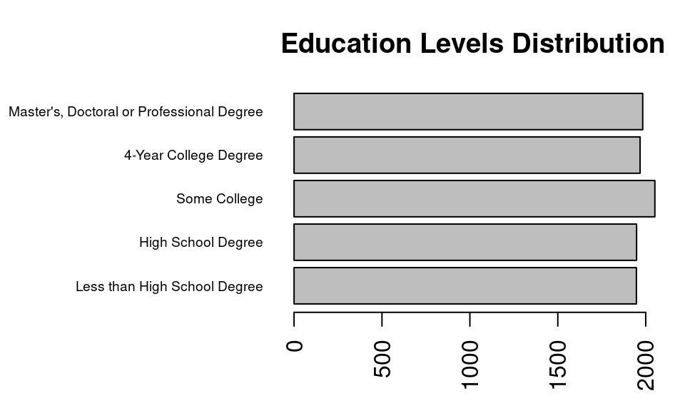

```r
# magins of the plot
# mar: A numerical vector of the form c(bottom, left, top, right) which gives
# the number of lines of margin to be specified on the four sides of the plot.
# The default is c(5, 4, 4, 2) + 0.1.
par(mar=c(3.5,10.5,3,1)+0.1)

#TODO why im using a table here?
counts <- table(ComResp$elevelLabeled)
# finally a Simple Horizontal Bar Plot with Added Labels
barplot(counts, main="Education Levels Distribution", horiz=TRUE, names.arg=ed_level_labels, cex.names=0.6, las=2)
```

> In general the education level of customers is very homogeneous.

### 4. Car

```r
cars_labels = c("BMW", "Buick", "Cadillac", "Chevrolet", "Chrysler", "Dodge", "Ford", "Honda", "Hyundai", "Jeep", "Kia", "Lincoln", "Mazda", "Mercedes Benz", "Mitsubishi", "Nissan", "Ram", "Subaru", "Toyota", "None of the above")

ComResp$carLabeled <- mapvalues(ComResp$car, from=c(0:19), to=cars_labels)
head(ComResp)
```

[output not shown]

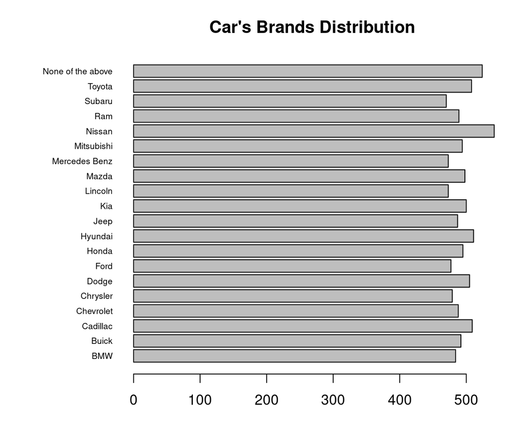

```r
# Simple Horizontal Bar Plot with Added Labels
par(mar=c(3,7.5,3,1)+0.1)
# mar: A numerical vector of the form c(bottom, left, top, right) which gives
# the number of lines of margin to be specified on the four sides of the plot.
# The default is c(5, 4, 4, 2) + 0.1.

Car_counts <- table(ComResp$carLabeled)

barplot(Car_counts, main="Car's Brands Distribution", horiz=TRUE, names.arg=cars_labels, cex.names=0.6, las=1,)
```

> There is no preffered car’s brand. the chocices are very homogeneous.

### 5. zipcode

5. What is your zip code?. Respondents enter zip code, which is captured as 1 of the following 9 regions in the U.S.  
   Value : Region  
   0 : New England  
   1 : Mid-Atlantic  
   2 : East North Central  
   3 : West North Central  
   4 : South Atlantic  
   5 : East South Central  
   6 : West South Central  
   7 : Mountain  
   8 : Pacific
- **This is a categorical Nominal variable**

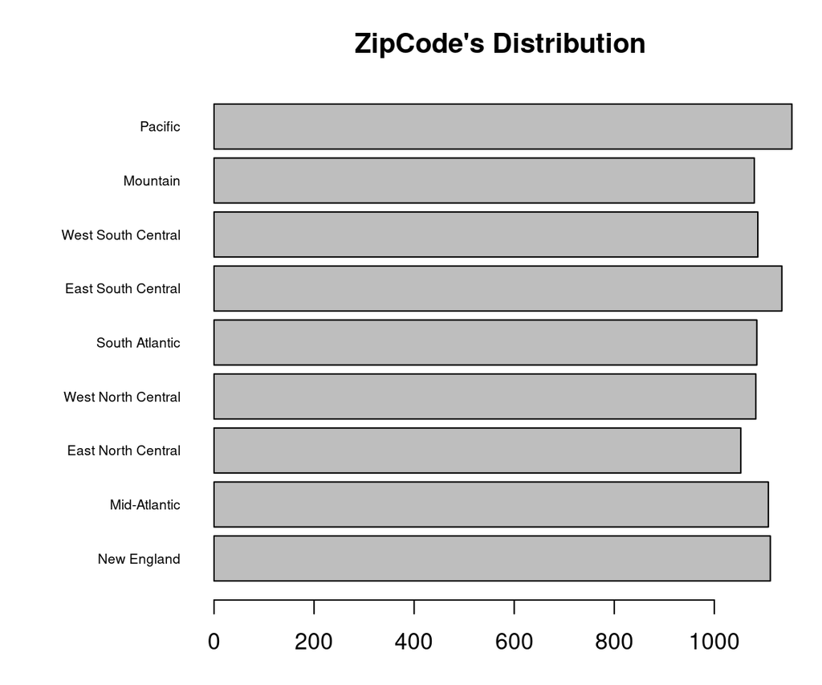

```r
zipcode_labels = c("New England", "Mid-Atlantic", "East North Central", "West North Central", "South Atlantic", "East South Central", "West South Central", "Mountain", "Pacific")

ComResp$zipcodeLabeled <- mapvalues(ComResp$zipcode, from=c(0:8), to=zipcode_labels)

# Simple Horizontal Bar Plot with Added Labels
par(mar=c(3,7.5,3,1)+0.1)
# mar: A numerical vector of the form c(bottom, left, top, right) which gives
# the number of lines of margin to be specified on the four sides of the plot.
# The default is c(5, 4, 4, 2) + 0.1.

zipcode_counts <- table(ComResp$zipcodeLabeled)

barplot(zipcode_counts, main="ZipCode's Distribution", horiz=TRUE, names.arg=zipcode_labels, cex.names=0.6, las=1,)
```

### 6. Credit

6. What amount of credit is available to you?. Respondents enter numeric value.
- **Quantitative variable**

```r
summary(ComResp$credit)
```

```
##    Min. 1st Qu.  Median    Mean 3rd Qu.    Max.
##       0  120807  250607  249176  374640  500000
```

[figure not shown]

```r
ggplot( ComResp, aes(x=credit)) + theme_bw()+
  geom_histogram(color = 'black', fill = '#FF6620', binwidth = 10000)+
  labs(title = "Credit Distribution", x="Salary") +
  geom_vline(aes(xintercept=mean(credit)), color="blue", linetype="dashed", size=1)  # adds the mean
```

### 7. brand

7. Which brand of computers do you prefer?. Respondents select from the following 2 choices:  
   Value : Description  
   0 : Acer  
   1 : Sony

> this is our Target variable.

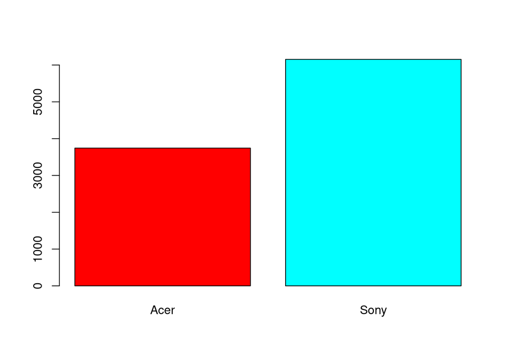

```r
brand_table <- table(ComResp$brand)

barplot(brand_table,
        col = rainbow(2),
        names.arg = c("Acer", "Sony"))
```

# FAST EDA

```r
library(skimr)
#library(DataExplorer)
```

## EDA Step 1 : Data Validation and Data Quality

```r
str(ComResp)
```

```
## 'data.frame':    9898 obs. of  10 variables:
##  $ salary        : num  119807 106880 78021 63690 50874 ...
##  $ age           : int  45 63 23 51 20 56 24 62 29 41 ...
##  $ elevel        : int  0 1 0 3 3 3 4 3 4 1 ...
##  $ car           : int  14 11 15 6 14 14 8 3 17 5 ...
##  $ zipcode       : int  4 6 2 5 4 3 5 0 0 4 ...
##  $ credit        : num  442038 45007 48795 40889 352951 ...
##  $ brand         : int  0 1 0 1 0 1 1 1 0 1 ...
##  $ elevelLabeled : chr  "Less than High School Degree" "High School Degree" "Less than High School Degree" "4-Year College Degree" ...
##  $ carLabeled    : chr  "Mitsubishi" "Lincoln" "Nissan" "Ford" ...
##  $ zipcodeLabeled: chr  "South Atlantic" "West South Central" "East North Central" "East South Central" ...
```

```r
skim(ComResp)
```

Data summary

| Name | ComResp |
| --- | --- |
| Number of rows | 9898 |
| Number of columns | 10 |
| _______________________ |  |
| Column type frequency: |  |
| character | 3 |
| numeric | 7 |
| ________________________ |  |
| Group variables | None |

**Variable type: character**

| skim_variable | n_missing | complete_rate | min | max | empty | n_unique | whitespace |
| --- | --- | --- | --- | --- | --- | --- | --- |
| elevelLabeled | 0 | 1 | 12 | 41 | 0 | 5 | 0 |
| carLabeled | 0 | 1 | 2 | 17 | 0 | 20 | 0 |
| zipcodeLabeled | 0 | 1 | 7 | 18 | 0 | 9 | 0 |

**Variable type: numeric**

| skim_variable | n_missing | complete_rate | mean | sd | p0 | p25 | p50 | p75 | p100 | hist |
| --- | --- | --- | --- | --- | --- | --- | --- | --- | --- | --- |
| salary | 0 | 1 | 84870.86 | 37712.34 | 20000 | 52082.11 | 84949.74 | 117162.04 | 150000 | ▇▇▇▇▇ |
| age | 0 | 1 | 49.78 | 17.60 | 20 | 35.00 | 50.00 | 65.00 | 80 | ▇▇▇▇▇ |
| elevel | 0 | 1 | 1.98 | 1.42 | 0 | 1.00 | 2.00 | 3.00 | 4 | ▇▇▇▇▇ |
| car | 0 | 1 | 10.52 | 5.77 | 1 | 6.00 | 11.00 | 15.75 | 20 | ▇▇▇▇▇ |
| zipcode | 0 | 1 | 4.04 | 2.58 | 0 | 2.00 | 4.00 | 6.00 | 8 | ▇▇▃▇▇ |
| credit | 0 | 1 | 249175.97 | 145211.57 | 0 | 120806.81 | 250607.15 | 374639.70 | 500000 | ▇▇▇▇▇ |
| brand | 0 | 1 | 0.62 | 0.48 | 0 | 0.00 | 1.00 | 1.00 | 1 | ▅▁▁▁▇ |